# Influence of UV irradiation on cSCC progression/metastasis assessed by epigenetic changes (miRNAs)

Marc Bender

# Preamble

This document serves as a summary of the data analysis conducted during my PhD thesis. It is structured chronologically to emphasize decision making based on the previous results. The basic question was if UV radiation influences tumor growth beyond initiation e.g. by induction of genomic changes or epigenetic alterations resulting in tumor progression and metastasis of cutaneous squamous cell carcinoma (cSCC). All miRNAs in the following study were human miRNAs. Data is available at:

- Fireplex Analysis: https://github.com/MBender1992/PhD/blob/Marc/Data/200619_chronic_irr_normalized.csv
- qPCR validation of fireplex results: https://github.com/MBender1992/PhD/blob/Marc/Data/qPCR_Validation.csv

### Loading of required packages

```r
# data wrangling and basic visualization
library(tidyverse)
library(ggpubr)
library(data.table)
# statistics
library(rstatix)
library(EnvStats)
# Heatmap
library(ComplexHeatmap)
library(circlize)
# PCA
library(FactoMineR)
library(factoextra)
# pathway analysis
library(RBiomirGS)
#
library(devtools)
# source custom R functions
source_url("https://raw.githubusercontent.com/MBender1992/base_scripts/Marc/R_functions.R")
```

# 1. Screening for UV induced miRNAs

## 1.1 Experimental setup and data ingestion

In a first step we screened 51 manually curated miRNAs associated with cSCC or other epithelial tumors for UV induced changes. To this end, five different cancer cell lines (SCL-II, Met-1, Met-4, SCC-12, SCC-13; Fig. 1) were grown under standard cell culture conditions with DMEM (Met-1,Met-4, SCL-II) or FAD (SCC-12, SCC-13) as cell culture media. Cells were grown to 80 % confluency and exposed to 103 kJ/m² (physical doses: 246.01 J/m² UVB (280-315 nm); 12.50 kJ/m² UVA (315-400 nm); 28.03 kJ/m² VIS (400-750 nm); 61.74 kJ/m² IR-A (750-1200 nm)) sunlight-equivalent radiation (SER) with a custom-built irradiation device (KAUVIR: https://www.fona.de/de/massnahmen/foerdermassnahmen/strahlenforschung.php). The cells were treated eight times with this dose over time course of 4 weeks to simulate a chronic UV exposure. For the analysis 4 biological replicates were used.

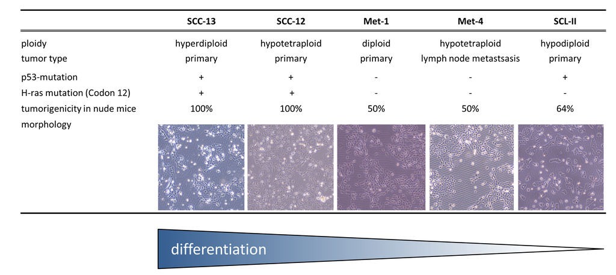

**Fig. 1: Cell line characteristics of the tumor cell lines used in this study.** The cell lines exhibit different levels of differentiation with SCC-13 being highly differentiated and SCL-II being undifferentiated. p53 mutations are present in all cell lines except Met-1 and Met-4. Met-1 and Met-4 are cell lines from the same patient in different stages of the tumor.)

After irradiation, cells were harvested and subjected to FirePlex immunoassay (abcam; https://www.abcam.com/nav/multiplex-assays/fireplex-immunoassays) to detect changes in miRNA expression using barcode-labelled probes. Data was imported to the complimentary workbench software and normalized to the 12 most stable miRNAs using the built-in algorithm.

```r
normalizers
```

```
 [1] "miR-23a-3p" "miR-23b-3p" "miR-24-3p"  "miR-26a-3p" "miR-30b-3p" "miR-22-3p"  "miR-16-5p"  "miR-221-3p"
 [9] "miR-15a-3p" "miR-29a-3p" "let-7f-5p"  "miR-29c-3p"
```

Subsequently, data was imported into R using the following function, to exclude miRNAs with a median expression below an arbitrary threshold, convert data from wide to tidy data and add a column with log2-transformed values as expression data follows a log-normal distribution (Beal 2017, https://ieeexplore.ieee.org/stamp/stamp.jsp?arnumber=7991639) :

```r
load_Fireplex_data_PhD <- function(filename, threshold)
{
  # check if required package is installed and load it
  if (!require(dplyr)) install.packages("dplyr")
  library(dplyr)

  #load data and change hyphens to underscores so r does not confuse a hyphen with minus
  dat <- read_csv(filename)
  names(dat) <- str_replace_all(names(dat), "-","_")
  # clean up the data, convert to tidy format and replace negative expression values with 0 as expression        cannot be negative
  dat_f <- dat %>%
    select(-Messung) %>%
    filter(cell_line != "HaCaT") %>%
    gather(miRNA, expression, -c(ID,cell_line, Irradiation)) %>%
    mutate(expression = ifelse(expression < 0, 0, expression))
  # index miRNAs with a median expression below the threshold
  ind <- dat_f %>%
    group_by(miRNA) %>%
    filter(median(expression, na.rm=TRUE) <= threshold) %>%
    .$miRNA %>%
    unique()
  # omit indexed miRNAs and add log2-transformed expression values
  dat_f %>%
    filter(!miRNA %in% ind) %>%
    mutate(log_exp = log2(expression+1)) %>%
    mutate(miRNA = str_replace_all(miRNA, "hsa_", "")) %>%
    mutate(miRNA = str_replace_all(miRNA, "_","-")) %>%
    mutate(cell_line = str_replace_all(cell_line, "-","_"))
}

url_file <- "https://raw.githubusercontent.com/MBender1992/PhD/Marc/Data/200619_chronic_irr_normalized.csv"
dat <-  load_Fireplex_data_PhD(filename = url(url_file), threshold = 2.5)
dat
```

| ID | cell_line | Irradiation | miRNA | expression | log_exp |
| --- | --- | --- | --- | --- | --- |
| 170419_Met-1_K01 | Met_1 | control | let-7c-5p | 995.769 | 9.9611154 |
| 170419_SCC-13_K01 | SCC_13 | control | let-7c-5p | 710.814 | 9.4753565 |
| 170419_Met-1_K02 | Met_1 | control | let-7c-5p | 1041.646 | 10.0260337 |
| 170419_SCC-13_K02 | SCC_13 | control | let-7c-5p | 1202.000 | 10.2324209 |
| 170419_Met-1_irr1 | Met_1 | KAUVIR | let-7c-5p | 805.048 | 9.6547219 |
| 170419_SCC-13_irr1 | SCC_13 | KAUVIR | let-7c-5p | 587.582 | 9.2010996 |
| 170419_ Met-1_irr2 | Met_1 | KAUVIR | let-7c-5p | 990.840 | 9.9539636 |
| 170419_SCC-13_irr2 | SCC_13 | KAUVIR | let-7c-5p | 551.080 | 9.1087335 |
| 170419_Met-4_K01 | Met_4 | control | let-7c-5p | 596.064 | 9.2217418 |
| 170419_SCL-II_K02A | SCL_II | control | let-7c-5p | 866.564 | 9.7608264 |

[output cut: 990 more lines]

## 1.2 Principal component analysis (PCA)

### 1.2.1 Theoretical Background

*Note: Explanation from Statquest (YouTube) concerning PCA. An illustration of principal components for an example with 2 variables:*

Data is plotted as var1 vs var2 (var1 on the x-axis, var2 on the y-axis). The center of this data is calculated and the data points are shifted so the center is at the origin (0,0). However, the relationship of the data points due to this rescaling did NOT change. A random line going through the origin is fitted, the original data points are projected onto this line and the distances from the origin to these projected points are calculated. The sum of squared distances (to avoid negative values cancelling out positive ones) is calculated as (SS(distances)):
$$\begin{aligned}
SS(distances) = d_{1}^2 + d_{2}^2 + ... + d_{n}^2
\end{aligned}$$
with n = sample size

The line is rotated around the origin and the line with the maximum SS(distances) becomes PC1. This lines’ slope can be used to calculate singular vectors or Eigenvectors by looking at how many units the line goes along the x-axis in positive direction (b) if moved 1 unit in positive direction of the y-axis (c). Using pythagorean theorem the distance a (value along the slope) is equal to:
$$\begin{aligned}
a = \sqrt{b^2+c^2}
\end{aligned}$$
which can be easily calculated.

- example: The slope is 0.25, then b=4 for c=1, using pythagorean theorem:

$$\begin{aligned}
a = \sqrt{b^2+c^2} = \sqrt{4^2+1^2} = \sqrt{16+1} = 4.12
\end{aligned}$$
a, b and c are then scaled by factor a, which in turn leads to a being 1:

$$\begin{aligned}
a(scaled) & = \frac{a}{a} = 1\\
b(scaled) & = \frac{b}{a} = 0.97\\
c(scaled) & = \frac{c}{a} = 0.242\\
\end{aligned}$$
This 1 unit long vector consisting of b(scaled) in the x-direction and c(scaled) in the y-direction is the Eigenvector consisting of 0.97 units var1 and 0.242 units var2. The Factors b(scaled) and c(scaled) are called loading scores and correspond to the importance of a particular variable to a principal component. In this example the loading scores tell us, in terms of how the values are projected onto PC1, var1 is 4 (0.97/0.242) times more important than var2.

In the case of only 2 variables PC2 is simply the line that is perpendicular to PC1. Then, the samples are also projected onto the PC2 axis. These projections of data on PC1 and PC2 on the PC1 and PC2 axis are then rotated so PC1 is horizontal. Afterwards out of these projections new positions for the samples are generated in the PC1 vs PC2 space.

The more dimensions the more complex this process gets, the PCs however are always perpendicular to each other and are uncorrelated. The issue of growing complexity when considering more than three dimensions can be solved mathematically as another word for SS(distances) is Eigenvalues, which can be computed by matrix algebra. Out of these Eigenvalues, the Eigenvectors can be constructed and eventually the PC lines can be generated even for high-dimensional data.

The variance of the PCs is simply the Eigenvalues or SS(distances) divided by the sample size minus one (n-1):
$$\begin{aligned}
var(PC_{i}) &= \frac{SS(distances(PC_{i}))}{n-1}\\
\end{aligned}$$
These variances can be used to calculate the proportion of variance in the data explained by each PC (variance explained) using the sum of variances :
$$\begin{aligned}
Sum(variances) = \sum_{i = 1}^n var(PC_{i})
\end{aligned}$$
To get the variance explained for each PC, the variance of the respective PC is divided by the sum of variances of all PCs.

- Example to calculate variance explained for PC1 if var(PC1) is 15 and var(PC2) is 3:

$$\begin{aligned}
\frac{var(PC_{1})}{\sum_{i = 1}^n var(PC_{i})} = \frac{var(PC_{1})}{var(PC_{1})+var(PC_{2})} = \frac{15}{15+3} = 0.8\bar3 = 83.\bar3 \ \%
\end{aligned}$$

In this example PC1 would explain 83.3 % of the variance in the data and PC2 would explain 16.7 % of the variance in the data. In R the prcomp function generates 3 parameters: x, sdev and rotation

- **x** contains the PCs to draw a graph
- **sdev** is the standard deviation of the PCs and can be transferred to the variance by squaring sdev and subsequently be used to calculate the variance explained
- **rotation** corresponds to the loading scores which show the importance of variables in respect to each PC